## Defense Version of the EDM

clear all

% set elasticities and shocks

%load Peanut.mat

%load Corn.mat

%load Rice.mat

%load Soybeans.mat

%load Wheat.mat

%load production.mat

%load Elast.mat

%load Elast2.mat

load Elast3.mat

load P0.mat

load Q.mat

load ss.mat

syms EP_corn EP_soy EP_wheat EP_rice EP_peanut

load wedge.mat

load B.mat

Results = struct;

Elast3.base.Demand.Corn= linspace(-0.696202, -0.9150616,10);

Elast3.base.Demand.Soy= linspace(-0.53614356, -0.7004875,10);

Elast3.base.Demand.Wheat= linspace(-0.20203276, -1.065577308, 10);

Elast3.base.Demand.Rice= linspace(-0.15688269, -0.66770675, 10);

Elast3.base.Demand.Peanuts = linspace(-0.23523965, -0.93527167, 10);

B.AOS.c(1:10) = 0.0;

B.AOS.s(1:10) = 0.0;

B.AOS.w(1:10) = 0.0;

B.AOS.r(1:10) = 0.0;

B.AOS.p(1:10) = 0.0;

B.FRS.c(1:10) = 0.0147;

B.FRS.s(1:10) = 0.005;

B.FRS.w(1:10) = 0.0166;

B.FRS.r(1:10) = 0.0046;

B.FRS.p(1:10) = 0.018;

distlist = {'base'}; %m

commodity = {'Corn', 'Soy', 'Wheat', 'Rice', 'Peanuts'}; %n

Run = {'wedge'};%i

i=1;

region = {'AOS','FRS'}; %j

dest = {'Demand','Exports', 'Imports','Supply'}; %a

cross = {'c','s','w','r','p'}; %c

yr = {1,10};

%%

for n = 1:length(commodity)

wedge.(commodity{n}).alpha = 0;

wedge.(commodity{n}).beta = 1;

end

format('short', 'g')

Find price changes. Here, price and quantity changes are calculated for each of the ten years even though we are only going to use years 1 (SR) and 10 (LR).

%% FIND PRICE CHANGES

% FOR EACH TIME PERIOD SOLVE FOR PRICE CHANGES, WITHIN EACH T LOOP SAVE

for t = 1:10

% if t == 1

eqns = [EP_corn * Elast3.base.Demand.Corn(t) + (EP_corn * wedge.Corn.beta) * (ss.exports_corn * Elast3.base.Exports.Corn(t) - ss.imports_corn * Elast3.base.Imports.Corn(t)) == ((ss.FRS_corn * (Elast3.base.Supply.FRS.cc(t) * EP_corn + Elast3.base.Supply.FRS.cs(t) * EP_soy + Elast3.base.Supply.FRS.cw(t) * EP_wheat + Elast3.base.Supply.FRS.cr(t) * EP_rice + Elast3.base.Supply.FRS.cp(t) * EP_peanut + B.FRS.c(t))) + (ss.AOS_corn * (Elast3.base.Supply.AOS.cc(t) * EP_corn + Elast3.base.Supply.AOS.cs(t) * EP_soy + Elast3.base.Supply.AOS.cw(t) * EP_wheat + Elast3.base.Supply.AOS.cr(t) * EP_rice + Elast3.base.Supply.AOS.cp(t) * EP_peanut + B.AOS.c(t)))),

EP_soy * Elast3.base.Demand.Soy(t) + (EP_soy * wedge.Soy.beta) * (ss.exports_soy * Elast3.base.Exports.Soy(t) - ss.imports_soy * Elast3.base.Imports.Soy(t)) == ((ss.FRS_soy * (Elast3.base.Supply.FRS.sc(t) * EP_corn + Elast3.base.Supply.FRS.ss(t) * EP_soy + Elast3.base.Supply.FRS.sw(t) * EP_wheat + Elast3.base.Supply.FRS.sr(t) * EP_rice + Elast3.base.Supply.FRS.sp(t) * EP_peanut + B.FRS.s(t))) + (ss.AOS_soy * (Elast3.base.Supply.AOS.sc(t) * EP_corn + Elast3.base.Supply.AOS.ss(t) * EP_soy + Elast3.base.Supply.AOS.sw(t) * EP_wheat + Elast3.base.Supply.AOS.sr(t) * EP_rice + Elast3.base.Supply.AOS.sp(t) * EP_peanut + B.AOS.s(t)))),

EP_wheat * Elast3.base.Demand.Wheat(t) + (EP_wheat * wedge.Wheat.beta) * (ss.exports_wheat * Elast3.base.Exports.Wheat(t) - ss.imports_wheat * Elast3.base.Imports.Wheat(t)) == ((ss.FRS_wheat * (Elast3.base.Supply.FRS.wc(t) * EP_corn + Elast3.base.Supply.FRS.ws(t) * EP_soy + Elast3.base.Supply.FRS.ww(t) * EP_wheat + Elast3.base.Supply.FRS.wr(t) * EP_rice + Elast3.base.Supply.FRS.wp(t) * EP_peanut + B.FRS.w(t))) + (ss.AOS_wheat * (Elast3.base.Supply.AOS.wc(t) * EP_corn + Elast3.base.Supply.AOS.ws(t) * EP_soy + Elast3.base.Supply.AOS.ww(t) * EP_wheat + Elast3.base.Supply.AOS.wr(t) * EP_rice + Elast3.base.Supply.AOS.wp(t) * EP_peanut + B.AOS.w(t)))),

EP_rice * Elast3.base.Demand.Rice(t) + (EP_rice * wedge.Rice.beta) * (ss.exports_rice * Elast3.base.Exports.Rice(t) - ss.imports_rice * Elast3.base.Imports.Rice(t)) == ((ss.FRS_rice * (Elast3.base.Supply.FRS.rc(t) * EP_corn + Elast3.base.Supply.FRS.rs(t) * EP_soy + Elast3.base.Supply.FRS.rw(t) * EP_wheat + Elast3.base.Supply.FRS.rr(t) * EP_rice + Elast3.base.Supply.FRS.rp(t) * EP_peanut + B.FRS.r(t))) + (ss.AOS_rice * (Elast3.base.Supply.AOS.rc(t) * EP_corn + Elast3.base.Supply.AOS.rs(t) * EP_soy + Elast3.base.Supply.AOS.rw(t) * EP_wheat + Elast3.base.Supply.AOS.rr(t) * EP_rice + Elast3.base.Supply.AOS.rp(t) * EP_peanut + B.AOS.r(t)))),

EP_peanut * Elast3.base.Demand.Peanuts(t) + (EP_peanut * wedge.Peanuts.beta) * (ss.exports_peanut * Elast3.base.Exports.Peanuts(t) - ss.imports_peanut * Elast3.base.Imports.Peanuts(t)) == ((ss.FRS_peanuts * (Elast3.base.Supply.FRS.pc(t) * EP_corn + Elast3.base.Supply.FRS.ps(t) * EP_soy + Elast3.base.Supply.FRS.pw(t) * EP_wheat + Elast3.base.Supply.FRS.pr(t) * EP_rice + Elast3.base.Supply.FRS.pp(t) * EP_peanut + B.FRS.p(t))) + (ss.AOS_peanuts * (Elast3.base.Supply.AOS.pc(t) * EP_corn + Elast3.base.Supply.AOS.ps(t) * EP_soy + Elast3.base.Supply.AOS.pw(t) * EP_wheat + Elast3.base.Supply.AOS.pr(t) * EP_rice + Elast3.base.Supply.AOS.pp(t) * EP_peanut + B.AOS.p(t))))];

x = [EP_corn, EP_soy, EP_wheat, EP_rice, EP_peanut];

[A, b] = equationsToMatrix(eqns, x);

X = double(linsolve(A,b));

for n = 1:length(commodity)

Results.EP.(commodity{n})(t) =...

X(n);

end

end

clear('t','n','X','x')

Rn = {'SR','LR'};

Corn = {Results.EP.Corn(1);Results.EP.Corn(10)};

Soy = {Results.EP.Soy(1);Results.EP.Soy(10)};

Wheat = {Results.EP.Wheat(1);Results.EP.Wheat(10)};

Rice = {Results.EP.Rice(1);Results.EP.Rice(10)};

Peanuts = {Results.EP.Peanuts(1);Results.EP.Peanuts(10)};

Pchg = table(Corn,Soy,Wheat,Rice,Peanuts,'RowNames',Rn)

Pchg =

**Corn** **Soy** **Wheat** **Rice** **Peanuts**  
**_____________** **_____________** **_____________** **_____________** **____________**  
**SR** [-0.00079741] [-0.00026936] [ -0.001528] [ -0.0012624] [ -0.021097]  
**LR** [-0.00030902] [ -0.0001695] [-0.00042086] [-0.00050655] [-0.0041963]

%% FIND QUANTITY CHANGES

% FIND DEMAND, EXPORT AND IMPORT CHANGES

for t = 1:10

Results.Demand.Corn(t) = Elast3.base.Demand.Corn(t) * Results.EP.Corn(t);

Results.Demand.Soy(t) = Elast3.base.Demand.Soy(t) * Results.EP.Soy(t);

Results.Demand.Wheat(t) = Elast3.base.Demand.Wheat(t) * Results.EP.Wheat(t);

Results.Demand.Rice(t) = Elast3.base.Demand.Rice(t) * Results.EP.Rice(t);

Results.Demand.Peanuts(t) = Elast3.base.Demand.Peanuts(t) * Results.EP.Peanuts(t);

%exports and imports change in response to a price change * wedge

Results.Exports.Corn(t) = Elast3.base.Exports.Corn(t) * Results.EP.Corn(t)* wedge.Corn.beta;

Results.Exports.Soy(t) = Elast3.base.Exports.Soy(t) * Results.EP.Soy(t)* wedge.Soy.beta;

Results.Exports.Wheat(t) = Elast3.base.Exports.Wheat(t) * Results.EP.Wheat(t)* wedge.Wheat.beta;

Results.Exports.Rice(t) = Elast3.base.Exports.Rice(t) * Results.EP.Rice(t)* wedge.Rice.beta;

Results.Exports.Peanuts(t) = Elast3.base.Exports.Peanuts(t) * Results.EP.Peanuts(t)* wedge.Peanuts.beta;

Results.Imports.Corn(t) = Elast3.base.Imports.Corn(t) * Results.EP.Corn(t)* wedge.Corn.beta;

Results.Imports.Soy(t) = Elast3.base.Imports.Soy(t) * Results.EP.Soy(t)* wedge.Soy.beta;

Results.Imports.Wheat(t) = Elast3.base.Imports.Wheat(t) * Results.EP.Wheat(t)* wedge.Wheat.beta;

Results.Imports.Rice(t) = Elast3.base.Imports.Rice(t) * Results.EP.Rice(t)* wedge.Rice.beta;

Results.Imports.Peanuts(t) = Elast3.base.Imports.Peanuts(t) * Results.EP.Peanuts(t)* wedge.Peanuts.beta;

end

clear('t','n','a');

%Find changes in supply quantities

for t = 1:10

Results.Supply.AOS.Corn(t) = Elast3.base.Supply.AOS.cc(t) *Results.EP.Corn(t) + Elast3.base.Supply.AOS.cs(t) * Results.EP.Soy(t) + Elast3.base.Supply.AOS.cw(t) * Results.EP.Wheat(t) + Elast3.base.Supply.AOS.cr(t) * Results.EP.Rice(t) + Elast3.base.Supply.AOS.cp(t) * Results.EP.Peanuts(t) + B.AOS.c(t);

Results.Supply.AOS.Soy(t) = Elast3.base.Supply.AOS.sc(t) *Results.EP.Corn(t) + Elast3.base.Supply.AOS.ss(t) * Results.EP.Soy(t) + Elast3.base.Supply.AOS.sw(t) * Results.EP.Wheat(t) + Elast3.base.Supply.AOS.sr(t) * Results.EP.Rice(t) + Elast3.base.Supply.AOS.sp(t) * Results.EP.Peanuts(t) + B.AOS.s(t);

Results.Supply.AOS.Wheat(t) = Elast3.base.Supply.AOS.wc(t) *Results.EP.Corn(t) + Elast3.base.Supply.AOS.ws(t) * Results.EP.Soy(t) + Elast3.base.Supply.AOS.ww(t) * Results.EP.Wheat(t) + Elast3.base.Supply.AOS.wr(t) * Results.EP.Rice(t) + Elast3.base.Supply.AOS.wp(t) * Results.EP.Peanuts(t) + B.AOS.w(t);

Results.Supply.AOS.Rice(t) = Elast3.base.Supply.AOS.rc(t) *Results.EP.Corn(t) + Elast3.base.Supply.AOS.rs(t) * Results.EP.Soy(t) + Elast3.base.Supply.AOS.rw(t) * Results.EP.Wheat(t) + Elast3.base.Supply.AOS.rr(t) * Results.EP.Rice(t) + Elast3.base.Supply.AOS.rp(t) * Results.EP.Peanuts(t) + B.AOS.r(t);

Results.Supply.AOS.Peanuts(t) = Elast3.base.Supply.AOS.pc(t) *Results.EP.Corn(t) + Elast3.base.Supply.AOS.ps(t) * Results.EP.Soy(t) + Elast3.base.Supply.AOS.pw(t) * Results.EP.Wheat(t) + Elast3.base.Supply.AOS.pr(t) * Results.EP.Rice(t) + Elast3.base.Supply.AOS.pp(t) * Results.EP.Peanuts(t) + B.AOS.p(t);

Results.Supply.FRS.Corn(t) = Elast3.base.Supply.FRS.cc(t) *Results.EP.Corn(t) + Elast3.base.Supply.FRS.cs(t) * Results.EP.Soy(t) + Elast3.base.Supply.FRS.cw(t) * Results.EP.Wheat(t) + Elast3.base.Supply.FRS.cr(t) * Results.EP.Rice(t) + Elast3.base.Supply.FRS.cp(t) * Results.EP.Peanuts(t) + B.FRS.c(t);

Results.Supply.FRS.Soy(t) = Elast3.base.Supply.FRS.sc(t) *Results.EP.Corn(t) + Elast3.base.Supply.FRS.ss(t) * Results.EP.Soy(t) + Elast3.base.Supply.FRS.sw(t) * Results.EP.Wheat(t) + Elast3.base.Supply.FRS.sr(t) * Results.EP.Rice(t) + Elast3.base.Supply.FRS.sp(t) * Results.EP.Peanuts(t) + B.FRS.s(t);

Results.Supply.FRS.Wheat(t) = Elast3.base.Supply.FRS.wc(t) *Results.EP.Corn(t) + Elast3.base.Supply.FRS.ws(t) * Results.EP.Soy(t) + Elast3.base.Supply.FRS.ww(t) * Results.EP.Wheat(t) + Elast3.base.Supply.FRS.wr(t) * Results.EP.Rice(t) + Elast3.base.Supply.FRS.wp(t) * Results.EP.Peanuts(t) + B.FRS.w(t);

Results.Supply.FRS.Rice(t) = Elast3.base.Supply.FRS.rc(t) *Results.EP.Corn(t) + Elast3.base.Supply.FRS.rs(t) * Results.EP.Soy(t) + Elast3.base.Supply.FRS.rw(t) * Results.EP.Wheat(t) + Elast3.base.Supply.FRS.rr(t) * Results.EP.Rice(t) + Elast3.base.Supply.FRS.rp(t) * Results.EP.Peanuts(t) + B.FRS.r(t);

Results.Supply.FRS.Peanuts(t) = Elast3.base.Supply.FRS.pc(t) *Results.EP.Corn(t) + Elast3.base.Supply.FRS.ps(t) * Results.EP.Soy(t) + Elast3.base.Supply.FRS.pw(t) * Results.EP.Wheat(t) + Elast3.base.Supply.FRS.pr(t) * Results.EP.Rice(t) + Elast3.base.Supply.FRS.pp(t) * Results.EP.Peanuts(t) + B.FRS.p(t);

end

Rn = {'SR','LR'};

Corn = {Results.Demand.Corn(1);Results.Demand.Corn(10)};

Soy = {Results.Demand.Soy(1);Results.Demand.Soy(10)};

Wheat = {Results.Demand.Wheat(1);Results.Demand.Wheat(10)};

Rice = {Results.Demand.Rice(1);Results.Demand.Rice(10)};

Peanuts = {Results.Demand.Peanuts(1);Results.Demand.Peanuts(10)};

Dchg = table(Corn,Soy,Wheat,Rice,Peanuts,'RowNames',Rn)

Dchg =

**Corn** **Soy** **Wheat** **Rice** **Peanuts**  
**____________** **____________** **____________** **____________** **___________**  
**SR** [0.00055516] [0.00014442] [0.00030871] [0.00019805] [ 0.004963]  
**LR** [0.00028277] [0.00011874] [0.00044846] [0.00033823] [0.0039246]

clear('Rn','Corn','Soy','Wheat','Rice','Peanuts')

Rn = {'SR','LR'};

Corn = {Results.Exports.Corn(1);Results.Exports.Corn(10)};

Soy = {Results.Exports.Soy(1);Results.Exports.Soy(10)};

Wheat = {Results.Exports.Wheat(1);Results.Exports.Wheat(10)};

Rice = {Results.Exports.Rice(1);Results.Exports.Rice(10)};

Peanuts = {Results.Exports.Peanuts(1);Results.Exports.Peanuts(10)};

Xchg = table(Corn,Soy,Wheat,Rice,Peanuts,'RowNames',Rn)

Xchg =

**Corn** **Soy** **Wheat** **Rice** **Peanuts**  
**____________** **____________** **___________** **___________** **__________**  
**SR** [0.00095689] [0.00067341] [0.0012988] [0.0033076] [0.021097]  
**LR** [0.00054788] [0.00068272] [0.0009937] [0.0023594] [0.021581]

clear('Rn','Corn','Soy','Wheat','Rice','Peanuts')

Rn = {'SR','LR'};

Corn = {Results.Imports.Corn(1);Results.Imports.Corn(10)};

Soy = {Results.Imports.Soy(1);Results.Imports.Soy(10)};

Wheat = {Results.Imports.Wheat(1);Results.Imports.Wheat(10)};

Rice = {Results.Imports.Rice(1);Results.Imports.Rice(10)};

Peanuts = {Results.Imports.Peanuts(1);Results.Imports.Peanuts(10)};

Ichg = table(Corn,Soy,Wheat,Rice,Peanuts,'RowNames',Rn)

Ichg =

**Corn** **Soy** **Wheat** **Rice** **Peanuts**  
**_____________** **_____________** **_____________** **_____________** **___________**  
**SR** [-0.00039871] [-0.00013468] [-0.00076402] [-0.00050497] [-0.010549]  
**LR** [ -0.00394] [ -0.000226] [ -0.0018097] [ -0.0015399] [-0.023616]

clear('Rn','Corn','Soy','Wheat','Rice','Peanuts')

Rn = {'SR','LR'};

Corn = {Results.Supply.AOS.Corn(1);Results.Supply.AOS.Corn(10)};

Soy = {Results.Supply.AOS.Soy(1);Results.Supply.AOS.Soy(10)};

Wheat = {Results.Supply.AOS.Wheat(1);Results.Supply.AOS.Wheat(10)};

Rice = {Results.Supply.AOS.Rice(1);Results.Supply.AOS.Rice(10)};

Peanuts = {Results.Supply.AOS.Peanuts(1);Results.Supply.AOS.Peanuts(10)};

AOSchg = table(Corn,Soy,Wheat,Rice,Peanuts,'RowNames',Rn)

AOSchg =

**Corn** **Soy** **Wheat** **Rice** **Peanuts**  
**_____________** **____________** **_____________** **_____________** **____________**  
**SR** [-0.00012508] [0.00010086] [-0.00015265] [ -0.000129] [-0.0073841]  
**LR** [-0.00042123] [8.4849e-05] [-0.00010776] [-0.00024441] [ -0.007903]

clear('Rn','Corn','Soy','Wheat','Rice','Peanuts')

Rn = {'SR','LR'};

Corn = {Results.Supply.FRS.Corn(1);Results.Supply.FRS.Corn(10)};

Soy = {Results.Supply.FRS.Soy(1);Results.Supply.FRS.Soy(10)};

Wheat = {Results.Supply.FRS.Wheat(1);Results.Supply.FRS.Wheat(10)};

Rice = {Results.Supply.FRS.Rice(1);Results.Supply.FRS.Rice(10)};

Peanuts = {Results.Supply.FRS.Peanuts(1);Results.Supply.FRS.Peanuts(10)};

FRSchg = table(Corn,Soy,Wheat,Rice,Peanuts,'RowNames',Rn)

FRSchg =

**Corn** **Soy** **Wheat** **Rice** **Peanuts**  
**__________** **___________** **__________** **___________** **__________**  
**SR** [0.014497] [0.0051054] [0.016176] [0.0040344] [0.010616]  
**LR** [0.013938] [0.0050861] [0.015964] [0.0034439] [0.010097]

clear('Rn','Corn','Soy','Wheat','Rice','Peanuts')

The ultimate goal was to calculate the changes in producer and consumer surplus. The following section will accomplish this goal. Again, a vector of prices for each commodity and all ten years even though only the first are and tenth year are in use.

format('short', 'g')

% Build vector of prices for each commodity for reference

for n = 1:length(commodity)

t = 1;

chg = Results.EP.(commodity{n})(1);

p0 = P0.(lower(commodity{n}(1)));

t0(n)= p0;

p1 = p0 * (1 + chg) ;

SR(n)= p1;

t = 10;

chg = Results.EP.(commodity{n})(10);

p10 = p0 * (1 + chg) ;

LR(n)= p10;

end

initPrice = {t0(1);t0(2);t0(3);t0(4);t0(5)};

PinSR = {SR(1);SR(2);SR(3);SR(4);SR(5)};

PinLR = {LR(1);LR(2);LR(3);LR(4);LR(5)};

Rn = {'Corn','Soy','Wheat','Rice','Peanuts'};

PricesT = table(initPrice ,PinSR,PinLR, 'RowNames',Rn)

PricesT =

**initPrice** **PinSR** **PinLR**  
**_________** **_________** **_________**  
**Corn** [4.11] [ 4.1067] [ 4.1087]  
**Soy** [12.5] [ 12.497] [ 12.498]  
**Wheat** [6.34] [ 6.3303] [ 6.3373]  
**Rice** [15.6] [ 15.58] [ 15.592]  
**Peanuts** [0.23] [0.22515] [0.22903]

% Build vector of quantities for each commodity for reference

for n = 1:length(commodity)

t0(n) = Q.(strcat((lower(commodity{n}(1))),'_','d','_0'));

t=1;

q1 = Q.(strcat((lower(commodity{n}(1))),'_','d','_0')) * (1 + Results.Demand.(commodity{n})(t));

SR(n)= q1;

t=10;

q10 = Q.(strcat((lower(commodity{n}(1))),'_','d','_0')) * (1 + Results.Demand.(commodity{n})(t));

LR(n)= q10;

end

initQd = {t0(1);t0(2);t0(3);t0(4);t0(5)};

QdinSR = {SR(1);SR(2);SR(3);SR(4);SR(5)};

QdinLR = {LR(1);LR(2);LR(3);LR(4);LR(5)};

Rn = {'Corn','Soy','Wheat','Rice','Peanuts'};

format('short', 'g')

QdT = table(initQd ,QdinSR,QdinLR, 'RowNames',Rn)

QdT =

**initQd** **QdinSR** **QdinLR**  
**____________** **____________** **____________**  
**Corn** [1.4216e+10] [1.4223e+10] [ 1.422e+10]  
**Soy** [3.9271e+09] [3.9277e+09] [3.9276e+09]  
**Wheat** [2.0263e+09] [2.0269e+09] [2.0272e+09]  
**Rice** [ 222215000] [2.2226e+08] [2.2229e+08]  
**Peanuts** [5.1887e+09] [5.2144e+09] [ 5.209e+09]

%% Change in Producer Surplus

for j = 1:length(region)

for n = 1:length(commodity)

t=1; % SR

P00 = P0.(lower(commodity{n}(1))); % set P naught

q00 = (Q.(strcat((lower(commodity{n}(1))),'_',(region{j}),'_0'))); % set Q naught

elast00 = Elast3.base.Supply.(region{j}).(strcat((lower(commodity{n}(1))),(lower(commodity{n}(1)))))(t);

slope00 = (1/elast00)*(P00/q00);

yintercept = P00 - slope00*(q00);

if yintercept < 0

qint0 = -yintercept/slope00;

%then it is the triangle from the x intercept

%and the box between p',q=0 and

%find triangle portion

triangle = (q00 - qint0)*P00*0.5;

%rectangle portion

rectangle = qint0 * P00;

PS0 = triangle + rectangle;

else %if y intercept >= 0 this is easy, find area to price axis

PS0 = (P00 - yintercept) * q00 * 0.5;

end

Results.PS0SR.(region{j}).(commodity{n}) = PS0;

P01 = P00 * (1+Results.EP.(commodity{n})(t));

q01 = q00 * (1+Results.Supply.(region{j}).(commodity{n})(t));

yintercept1 = P01 - slope00*(q01);

if yintercept1 < 0

qint1 = -yintercept1/slope00;

%find triangle portion

triangle1 = (q01 - qint1)*P01*0.5;

%rectangle portion

rectangle1 = qint1 * P01;

PS1 = triangle1 + rectangle1;

else

PS1 = (P01 - yintercept1) * q01 * 0.5;

end

Results.PSNewSR.(region{j}).(commodity{n}) = PS1;

Results.ChgPSSR.(region{j}).(commodity{n}) = PS1 - PS0;

t = 10; % LR

P00 = P0.(lower(commodity{n}(1))); % set P naught

q00 = (Q.(strcat((lower(commodity{n}(1))),'_',(region{j}),'_0'))); % set Q naught

elast00 = Elast3.base.Supply.(region{j}).(strcat((lower(commodity{n}(1))),(lower(commodity{n}(1)))))(t);

slope00 = (1/elast00)*(P00/q00);

yintercept = P00 - slope00*(q00);

if yintercept < 0

qint0 = -yintercept/slope00;

%then it is the triangle from the x intercept

%and the box between p',q=0 and

%find triangle portion

triangle = (q00 - qint0)*P00*0.5;

%rectangle portion

rectangle = qint0 * P00;

PS0 = triangle + rectangle;

else %if y intercept >= 0 this is easy, find area to price axis

PS0 = (P00 - yintercept) * q00 * 0.5;

end

Results.PS0LR.(region{j}).(commodity{n}) = PS0;

P01 = P0.(lower(commodity{n}(1))) * (1+Results.EP.(commodity{n})(t));

q01 = (Q.(strcat((lower(commodity{n}(1))),'_',(region{j}),'_0')))* (1+Results.Supply.(region{j}).(commodity{n})(t));

elast01 = Elast3.base.Supply.(region{j}).(strcat((lower(commodity{n}(1))),(lower(commodity{n}(1)))))(t);

yintercept1 = P01 - slope00*(q01);

if yintercept1 < 0

qint1 = -yintercept1/slope00;

%find triangle portion

triangle1 = (q01 - qint1)*P01*0.5;

%rectangle portion

rectangle1 = qint1 * P01;

PS1 = triangle1 + rectangle1;

else

PS1 = (P01 - yintercept1) * q01 * 0.5;

end

Results.PSNewLR.(region{j}).(commodity{n}) = PS1;

Results.ChgPSLR.(region{j}).(commodity{n}) = ...

PS1 - ...

PS0;

end

end

format('bank')

Rn = {'SR','LR'};

Corn = {Results.ChgPSSR.FRS.Corn;Results.ChgPSLR.FRS.Corn};

Soy = {Results.ChgPSSR.FRS.Soy;Results.ChgPSLR.FRS.Soy};

Wheat = {Results.ChgPSSR.FRS.Wheat;Results.ChgPSLR.FRS.Wheat};

Rice = {Results.ChgPSSR.FRS.Rice;Results.ChgPSLR.FRS.Rice};

Peanuts = {Results.ChgPSSR.FRS.Peanuts;Results.ChgPSLR.FRS.Peanuts};

PSFRSchg = table(Corn,Soy,Wheat,Rice,Peanuts,'RowNames',Rn)

PSFRSchg =

**Corn** **Soy** **Wheat** **Rice** **Peanuts**  
**_____________** **_____________** **_____________** **____________** **_____________**  
**SR** [45509460.90] [28882343.67] [18938125.16] [8906683.41] [-3943908.20]  
**LR** [14047513.92] [29631295.30] [ 9906258.38] [3755197.50] [ 6251552.15]

clear('Rn','Corn','Soy','Wheat','Rice','Peanuts')

Rn = {'SR','LR'};

Corn = {Results.ChgPSSR.AOS.Corn;Results.ChgPSLR.AOS.Corn};

Soy = {Results.ChgPSSR.AOS.Soy;Results.ChgPSLR.AOS.Soy};

Wheat = {Results.ChgPSSR.AOS.Wheat;Results.ChgPSLR.AOS.Wheat};

Rice = {Results.ChgPSSR.AOS.Rice;Results.ChgPSLR.AOS.Rice};

Peanuts = {Results.ChgPSSR.AOS.Peanuts;Results.ChgPSLR.AOS.Peanuts};

PSAOSchg = table(Corn,Soy,Wheat,Rice,Peanuts,'RowNames',Rn)

PSAOSchg =

**Corn** **Soy** **Wheat** **Rice** **Peanuts**  
**______________** **_____________** **______________** **____________** **____________**  
**SR** [-42043743.97] [-5497574.08] [-15926378.11] [-893118.10] [-697618.47]  
**LR** [-11557970.48] [ -296768.24] [ -1011949.47] [-163441.47] [-138719.58]

clear('Rn','Corn','Soy','Wheat','Rice','Peanuts')

% find the change in CS

for n = 1:length(commodity)

t = 1;

Pd = P0.(lower(commodity{n}(1)));

qd = Q.(strcat((lower(commodity{n}(1))),'_','d','_0'));

elast = Elast3.base.Demand.(commodity{n})(t);

sloped00 = round((1 / elast) * (Pd/qd),3,'significant');

yinterceptd00 = Pd - sloped00*(qd);

CS0 = (yinterceptd00 - Pd) * qd * 0.5;

Results.CS0SR.(commodity{n}) = CS0;

Pdt = P0.(lower(commodity{n}(1))) * (1 + Results.EP.(commodity{n})(1)) ;

qdt = Q.(strcat((lower(commodity{n}(1))),'_','d','_0')) * (1 + Results.Demand.(commodity{n})(t));

yintercept0001 = Pdt - sloped00 * (qdt);

CS1= (yintercept0001 - Pdt) * qdt * 0.5;

Results.CS1SR.(commodity{n}) = CS1;

Results.chg_CS_SR.(commodity{n}) = CS1 - CS0;

chgCStable(n,1) = Results.chg_CS_SR.(commodity{n});

t = 10;

Pd = P0.(lower(commodity{n}(1)));

qd = Q.(strcat((lower(commodity{n}(1))),'_','d','_0'));

elast = Elast3.base.Demand.(commodity{n})(t);

sloped00 = round((1 / elast) * (Pd/qd),3,'significant');

yinterceptd00 = Pd - sloped00*(qd);

CS0 = (yinterceptd00 - Pd) * qd * 0.5;

Results.CS0LR_LR.(commodity{n}) = CS0;

Pdt = P0.(lower(commodity{n}(1))) * (1 + Results.EP.(commodity{n})(10)) ;

qdt = Q.(strcat((lower(commodity{n}(1))),'_','d','_0')) * (1 + Results.Demand.(commodity{n})(t));

yintercept0001 = Pdt - sloped00 * (qdt);

CS1 = (yintercept0001 - Pdt) * qdt * 0.5;

Results.CS1LR.(commodity{n}) = CS1;

Results.chg_CS_LR.(commodity{n}) = CS1 - CS0;

chgCStable(n,2) = Results.chg_CS_LR.(commodity{n});

end

chgCStable

chgCStable =

46570658.87 18059735.23  
13230541.54 8313866.06  
19650215.60 5414775.82  
4371992.01 1753963.05  
25181767.32 5018129.53

%Net Change In Surplus

Results.BaseSR.CS = Results.chg_CS_SR.Corn + Results.chg_CS_SR.Soy + Results.chg_CS_SR.Wheat + Results.chg_CS_SR.Rice + Results.chg_CS_SR.Peanuts ;

Results.BaseLR.CS = Results.chg_CS_LR.Corn + Results.chg_CS_LR.Soy + Results.chg_CS_LR.Wheat + Results.chg_CS_LR.Rice + Results.chg_CS_LR.Peanuts;

Results.BaseSR.PSAOS = Results.ChgPSSR.AOS.Corn + Results.ChgPSSR.AOS.Soy + Results.ChgPSSR.AOS.Wheat + Results.ChgPSSR.AOS.Rice + Results.ChgPSSR.AOS.Peanuts;

Results.BaseLR.PSAOS = Results.ChgPSLR.AOS.Corn + Results.ChgPSLR.AOS.Soy + Results.ChgPSLR.AOS.Wheat + Results.ChgPSLR.AOS.Rice + Results.ChgPSLR.AOS.Peanuts;

Results.BaseSR.PSFRS = Results.ChgPSSR.FRS.Corn + Results.ChgPSSR.FRS.Soy + Results.ChgPSSR.FRS.Wheat + Results.ChgPSSR.FRS.Rice + Results.ChgPSSR.FRS.Peanuts;

Results.BaseLR.PSFRS = Results.ChgPSLR.FRS.Corn + Results.ChgPSLR.FRS.Soy + Results.ChgPSLR.FRS.Wheat + Results.ChgPSLR.FRS.Rice + Results.ChgPSLR.FRS.Peanuts;

Results.BaseSR.PS = Results.BaseSR.PSAOS + Results.BaseSR.PSFRS;

Results.BaseLR.PS = Results.BaseLR.PSAOS + Results.BaseLR.PSFRS;

Results.BaseSR.Net = Results.BaseSR.CS + Results.BaseSR.PS;

Results.BaseLR.Net = Results.BaseLR.CS + Results.BaseLR.PS;

Rn = {'SR','LR'};

ConsumerSurplusChange = {Results.BaseSR.CS;Results.BaseLR.CS};

ProducerSurplusAOSChange = {Results.BaseSR.PSAOS;Results.BaseLR.PSAOS};

ProducerSurplusFRSChange = {Results.BaseSR.PSFRS;Results.BaseLR.PSFRS};

NetSurplusChange = {Results.BaseSR.Net;Results.BaseLR.Net};

SurpluschgBase = table(ConsumerSurplusChange,ProducerSurplusAOSChange,ProducerSurplusFRSChange,NetSurplusChange,'RowNames',Rn)

SurpluschgBase =

**ConsumerSurplusChange** **ProducerSurplusAOSChange** **ProducerSurplusFRSChange** **NetSurplusChange**  
**_____________________** **________________________** **________________________** **________________**  
**SR** [109005175.32] [-65058432.72] [98292704.94] [142239447.55]  
**LR** [ 38560469.69] [-13168849.24] [63591817.25] [ 88983437.70]

base= figure('Name','Results');

dat = {'Change Corn Price', Results.EP.Corn(1), Results.EP.Corn(10);...

'Change Soy Price', Results.EP.Soy(1),Results.EP.Soy(10);...

'Change Wheat Price', Results.EP.Wheat(1), Results.EP.Wheat(10);...

'Change Rice Price', Results.EP.Rice(1), Results.EP.Rice(10);...

'Change Peanuts Price', Results.EP.Peanuts(1), Results.EP.Peanuts(10);...

;...

'Change Corn Q Demanded', Results.Demand.Corn(1), Results.Demand.Corn(10);...

'Change Soy Q Demanded', Results.Demand.Soy(1), Results.Demand.Soy(10);...

'Change Wheat Q Demanded', Results.Demand.Wheat(1), Results.Demand.Wheat(10);...

'Change Rice Q Demanded', Results.Demand.Rice(1), Results.Demand.Rice(10);...

'Change Peanuts Q Demanded', Results.Demand.Peanuts(1), Results.Demand.Peanuts(10);...

;...

'Change Corn Q Supplied AOS', Results.Supply.AOS.Corn(1), Results.Supply.AOS.Corn(10);...

'Change Soy Q Supplied AOS', Results.Supply.AOS.Soy(1), Results.Supply.AOS.Soy(10);...

'Change Wheat Q Supplied AOS', Results.Supply.AOS.Wheat(1), Results.Supply.AOS.Wheat(10);...

'Change Rice Q Supplied AOS', Results.Supply.AOS.Rice(1), Results.Supply.AOS.Rice(10);...

'Change Peanuts Q Supplied AOS', Results.Supply.AOS.Peanuts(1), Results.Supply.AOS.Peanuts(10);...

;...

'Change Corn Q Supplied FRS', Results.Supply.FRS.Corn(1), Results.Supply.FRS.Corn(10);...

'Change Soy Q Supplied FRS', Results.Supply.FRS.Soy(1), Results.Supply.FRS.Soy(10);...

'Change Wheat Q Supplied FRS', Results.Supply.FRS.Wheat(1), Results.Supply.FRS.Wheat(10);...

'Change Rice Q Supplied FRS', Results.Supply.FRS.Rice(1), Results.Supply.FRS.Rice(10);...

'Change Peanuts Q Supplied FRS', Results.Supply.FRS.Peanuts(1), Results.Supply.FRS.Peanuts(10);...

;...

' Change Consumer Surplus Corn', Results.chg_CS_SR.Corn, Results.chg_CS_LR.Corn ;...

' Change Consumer Surplus Soy', Results.chg_CS_SR.Soy,Results.chg_CS_LR.Soy;...

' Change Consumer Surplus Wheat', Results.chg_CS_SR.Wheat,Results.chg_CS_LR.Wheat;...

' Change Consumer Surplus Rice', Results.chg_CS_SR.Rice,Results.chg_CS_LR.Rice;...

' Change Consumer Surplus Peanuts', Results.chg_CS_SR.Peanuts,Results.chg_CS_LR.Peanuts;...

;...

' Change Producer Surplus Corn AOS', Results.ChgPSSR.AOS.Corn,Results.ChgPSLR.AOS.Corn ;...

' Change Producer Surplus Soy AOS', Results.ChgPSSR.AOS.Soy,Results.ChgPSLR.AOS.Soy ;...

' Change Producer Surplus Wheat AOS', Results.ChgPSSR.AOS.Wheat,Results.ChgPSLR.AOS.Wheat ;...

' Change Producer Surplus Rice AOS', Results.ChgPSSR.AOS.Rice,Results.ChgPSLR.AOS.Rice ;...

' Change Producer Surplus Peanuts AOS', Results.ChgPSSR.AOS.Peanuts, Results.ChgPSLR.AOS.Peanuts;...

;...

' Change Producer Surplus Corn FRS', Results.ChgPSSR.FRS.Corn,Results.ChgPSLR.FRS.Corn ;...

' Change Producer Surplus Soy FRS', Results.ChgPSSR.FRS.Soy, Results.ChgPSLR.FRS.Soy;...

' Change Producer Surplus Wheat FRS', Results.ChgPSSR.FRS.Wheat,Results.ChgPSLR.FRS.Wheat ;...

' Change Producer Surplus Rice FRS', Results.ChgPSSR.FRS.Rice, Results.ChgPSLR.FRS.Rice;...

' Change Producer Surplus Peanuts FRS', Results.ChgPSSR.FRS.Peanuts, Results.ChgPSLR.FRS.Peanuts...

};

colname = {'Result','SR','LR'};

baseTable = uitable('Units','normalized','Data', dat, 'ColumnName', colname);

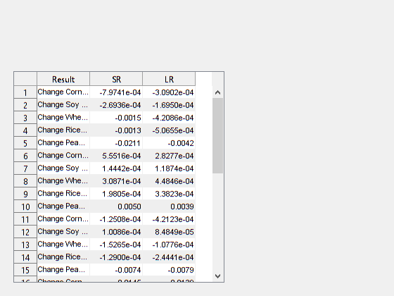

%%

## Alternate Import and Export Elasticities

Elast3.base.Imports.Corn(1) = 0.5;

Elast3.base.Imports.Soy(1) = 0.5;

Elast3.base.Imports.Wheat(1) = 0.5;

Elast3.base.Imports.Rice(1) = 0.5;

Elast3.base.Imports.Peanuts(1) = 0.5;

Elast3.base.Imports.Corn(10) = 1;

Elast3.base.Imports.Soy(10) = 1;

Elast3.base.Imports.Wheat(10) = 1;

Elast3.base.Imports.Rice(10) = 1;

Elast3.base.Imports.Peanuts(10) = 1;

% Elast3.base.Exports.Corn(1) = 0.5;

% Elast3.base.Exports.Soy(1) = 0.5;

% Elast3.base.Exports.Wheat(1) = 0.5;

% Elast3.base.Exports.Rice(1) = 0.5;

% Elast3.base.Exports.Peanuts(1) = 0.5;

%

% Elast3.base.Exports.Corn(10) = 1;

% Elast3.base.Exports.Soy(10) = 1;

% Elast3.base.Exports.Wheat(10) = 1;

% Elast3.base.Exports.Rice(10) = 1;

% Elast3.base.Exports.Peanuts(10) = 1;

%% FIND PRICE CHANGES

% FOR EACH TIME PERIOD SOLVE FOR PRICE CHANGES, WITHIN EACH T LOOP SAVE

for t = 1:10

% if t == 1

eqns = [EP_corn * Elast3.base.Demand.Corn(t) + (EP_corn * wedge.Corn.beta) * (ss.exports_corn * Elast3.base.Exports.Corn(t) - ss.imports_corn * Elast3.base.Imports.Corn(t)) == ((ss.FRS_corn * (Elast3.base.Supply.FRS.cc(t) * EP_corn + Elast3.base.Supply.FRS.cs(t) * EP_soy + Elast3.base.Supply.FRS.cw(t) * EP_wheat + Elast3.base.Supply.FRS.cr(t) * EP_rice + Elast3.base.Supply.FRS.cp(t) * EP_peanut + B.FRS.c(t))) + (ss.AOS_corn * (Elast3.base.Supply.AOS.cc(t) * EP_corn + Elast3.base.Supply.AOS.cs(t) * EP_soy + Elast3.base.Supply.AOS.cw(t) * EP_wheat + Elast3.base.Supply.AOS.cr(t) * EP_rice + Elast3.base.Supply.AOS.cp(t) * EP_peanut + B.AOS.c(t)))),

EP_soy * Elast3.base.Demand.Soy(t) + (EP_soy * wedge.Soy.beta) * (ss.exports_soy * Elast3.base.Exports.Soy(t) - ss.imports_soy * Elast3.base.Imports.Soy(t)) == ((ss.FRS_soy * (Elast3.base.Supply.FRS.sc(t) * EP_corn + Elast3.base.Supply.FRS.ss(t) * EP_soy + Elast3.base.Supply.FRS.sw(t) * EP_wheat + Elast3.base.Supply.FRS.sr(t) * EP_rice + Elast3.base.Supply.FRS.sp(t) * EP_peanut + B.FRS.s(t))) + (ss.AOS_soy * (Elast3.base.Supply.AOS.sc(t) * EP_corn + Elast3.base.Supply.AOS.ss(t) * EP_soy + Elast3.base.Supply.AOS.sw(t) * EP_wheat + Elast3.base.Supply.AOS.sr(t) * EP_rice + Elast3.base.Supply.AOS.sp(t) * EP_peanut + B.AOS.s(t)))),

EP_wheat * Elast3.base.Demand.Wheat(t) + (EP_wheat * wedge.Wheat.beta) * (ss.exports_wheat * Elast3.base.Exports.Wheat(t) - ss.imports_wheat * Elast3.base.Imports.Wheat(t)) == ((ss.FRS_wheat * (Elast3.base.Supply.FRS.wc(t) * EP_corn + Elast3.base.Supply.FRS.ws(t) * EP_soy + Elast3.base.Supply.FRS.ww(t) * EP_wheat + Elast3.base.Supply.FRS.wr(t) * EP_rice + Elast3.base.Supply.FRS.wp(t) * EP_peanut + B.FRS.w(t))) + (ss.AOS_wheat * (Elast3.base.Supply.AOS.wc(t) * EP_corn + Elast3.base.Supply.AOS.ws(t) * EP_soy + Elast3.base.Supply.AOS.ww(t) * EP_wheat + Elast3.base.Supply.AOS.wr(t) * EP_rice + Elast3.base.Supply.AOS.wp(t) * EP_peanut + B.AOS.w(t)))),

EP_rice * Elast3.base.Demand.Rice(t) + (EP_rice * wedge.Rice.beta) * (ss.exports_rice * Elast3.base.Exports.Rice(t) - ss.imports_rice * Elast3.base.Imports.Rice(t)) == ((ss.FRS_rice * (Elast3.base.Supply.FRS.rc(t) * EP_corn + Elast3.base.Supply.FRS.rs(t) * EP_soy + Elast3.base.Supply.FRS.rw(t) * EP_wheat + Elast3.base.Supply.FRS.rr(t) * EP_rice + Elast3.base.Supply.FRS.rp(t) * EP_peanut + B.FRS.r(t))) + (ss.AOS_rice * (Elast3.base.Supply.AOS.rc(t) * EP_corn + Elast3.base.Supply.AOS.rs(t) * EP_soy + Elast3.base.Supply.AOS.rw(t) * EP_wheat + Elast3.base.Supply.AOS.rr(t) * EP_rice + Elast3.base.Supply.AOS.rp(t) * EP_peanut + B.AOS.r(t)))),

EP_peanut * Elast3.base.Demand.Peanuts(t) + (EP_peanut * wedge.Peanuts.beta) * (ss.exports_peanut * Elast3.base.Exports.Peanuts(t) - ss.imports_peanut * Elast3.base.Imports.Peanuts(t)) == ((ss.FRS_peanuts * (Elast3.base.Supply.FRS.pc(t) * EP_corn + Elast3.base.Supply.FRS.ps(t) * EP_soy + Elast3.base.Supply.FRS.pw(t) * EP_wheat + Elast3.base.Supply.FRS.pr(t) * EP_rice + Elast3.base.Supply.FRS.pp(t) * EP_peanut + B.FRS.p(t))) + (ss.AOS_peanuts * (Elast3.base.Supply.AOS.pc(t) * EP_corn + Elast3.base.Supply.AOS.ps(t) * EP_soy + Elast3.base.Supply.AOS.pw(t) * EP_wheat + Elast3.base.Supply.AOS.pr(t) * EP_rice + Elast3.base.Supply.AOS.pp(t) * EP_peanut + B.AOS.p(t))))];

x = [EP_corn, EP_soy, EP_wheat, EP_rice, EP_peanut];

[A, b] = equationsToMatrix(eqns, x);

X = double(linsolve(A,b));

for n = 1:length(commodity)

ResultsIE.EP.(commodity{n})(t) =...

X(n);

end

end

clear('t','n','X','x')

Rn = {'SR','LR'};

Corn = {ResultsIE.EP.Corn(1);ResultsIE.EP.Corn(10)};

Soy = {ResultsIE.EP.Soy(1);ResultsIE.EP.Soy(10)};

Wheat = {ResultsIE.EP.Wheat(1);ResultsIE.EP.Wheat(10)};

Rice = {ResultsIE.EP.Rice(1);ResultsIE.EP.Rice(10)};

Peanuts = {ResultsIE.EP.Peanuts(1);ResultsIE.EP.Peanuts(10)};

Pchg = table(Corn,Soy,Wheat,Rice,Peanuts,'RowNames',Rn)

Pchg =

**Corn** **Soy** **Wheat** **Rice** **Peanuts**  
**_______** **_______** **_______** **_______** **_______**  
**SR** [-0.00] [-0.00] [-0.00] [-0.00] [-0.02]  
**LR** [-0.00] [-0.00] [-0.00] [-0.00] [-0.00]

clear('Rn','Corn','Soy','Wheat','Rice','Peanuts')

%% FIND QUANTITY CHANGES

% FIND DEMAND, EXPORT AND IMPORT CHANGES

for t = 1:10

ResultsIE.Demand.Corn(t) = Elast3.base.Demand.Corn(t) * ResultsIE.EP.Corn(t);

ResultsIE.Demand.Soy(t) = Elast3.base.Demand.Soy(t) * ResultsIE.EP.Soy(t);

ResultsIE.Demand.Wheat(t) = Elast3.base.Demand.Wheat(t) * ResultsIE.EP.Wheat(t);

ResultsIE.Demand.Rice(t) = Elast3.base.Demand.Rice(t) * ResultsIE.EP.Rice(t);

ResultsIE.Demand.Peanuts(t) = Elast3.base.Demand.Peanuts(t) * ResultsIE.EP.Peanuts(t);

%exports and imports change in response to a price change * wedge

ResultsIE.Exports.Corn(t) = Elast3.base.Exports.Corn(t) * ResultsIE.EP.Corn(t)* wedge.Corn.beta;

ResultsIE.Exports.Soy(t) = Elast3.base.Exports.Soy(t) * ResultsIE.EP.Soy(t)* wedge.Soy.beta;

ResultsIE.Exports.Wheat(t) = Elast3.base.Exports.Wheat(t) * ResultsIE.EP.Wheat(t)* wedge.Wheat.beta;

ResultsIE.Exports.Rice(t) = Elast3.base.Exports.Rice(t) * ResultsIE.EP.Rice(t)* wedge.Rice.beta;

ResultsIE.Exports.Peanuts(t) = Elast3.base.Exports.Peanuts(t) * ResultsIE.EP.Peanuts(t)* wedge.Peanuts.beta;

ResultsIE.Imports.Corn(t) = Elast3.base.Imports.Corn(t) * ResultsIE.EP.Corn(t)* wedge.Corn.beta;

ResultsIE.Imports.Soy(t) = Elast3.base.Imports.Soy(t) * ResultsIE.EP.Soy(t)* wedge.Soy.beta;

ResultsIE.Imports.Wheat(t) = Elast3.base.Imports.Wheat(t) * ResultsIE.EP.Wheat(t)* wedge.Wheat.beta;

ResultsIE.Imports.Rice(t) = Elast3.base.Imports.Rice(t) * ResultsIE.EP.Rice(t)* wedge.Rice.beta;

ResultsIE.Imports.Peanuts(t) = Elast3.base.Imports.Peanuts(t) * ResultsIE.EP.Peanuts(t)* wedge.Peanuts.beta;

end

clear('t','n','a');

%Find changes in supply quantities

for t = 1:10

ResultsIE.Supply.AOS.Corn(t) = Elast3.base.Supply.AOS.cc(t) *ResultsIE.EP.Corn(t) + Elast3.base.Supply.AOS.cs(t) * ResultsIE.EP.Soy(t) + Elast3.base.Supply.AOS.cw(t) * ResultsIE.EP.Wheat(t) + Elast3.base.Supply.AOS.cr(t) * ResultsIE.EP.Rice(t) + Elast3.base.Supply.AOS.cp(t) * ResultsIE.EP.Peanuts(t) + B.AOS.c(t);

ResultsIE.Supply.AOS.Soy(t) = Elast3.base.Supply.AOS.sc(t) *ResultsIE.EP.Corn(t) + Elast3.base.Supply.AOS.ss(t) * ResultsIE.EP.Soy(t) + Elast3.base.Supply.AOS.sw(t) * ResultsIE.EP.Wheat(t) + Elast3.base.Supply.AOS.sr(t) * ResultsIE.EP.Rice(t) + Elast3.base.Supply.AOS.sp(t) * ResultsIE.EP.Peanuts(t) + B.AOS.s(t);

ResultsIE.Supply.AOS.Wheat(t) = Elast3.base.Supply.AOS.wc(t) *ResultsIE.EP.Corn(t) + Elast3.base.Supply.AOS.ws(t) * ResultsIE.EP.Soy(t) + Elast3.base.Supply.AOS.ww(t) * ResultsIE.EP.Wheat(t) + Elast3.base.Supply.AOS.wr(t) * ResultsIE.EP.Rice(t) + Elast3.base.Supply.AOS.wp(t) * ResultsIE.EP.Peanuts(t) + B.AOS.w(t);

ResultsIE.Supply.AOS.Rice(t) = Elast3.base.Supply.AOS.rc(t) *ResultsIE.EP.Corn(t) + Elast3.base.Supply.AOS.rs(t) * ResultsIE.EP.Soy(t) + Elast3.base.Supply.AOS.rw(t) * ResultsIE.EP.Wheat(t) + Elast3.base.Supply.AOS.rr(t) * ResultsIE.EP.Rice(t) + Elast3.base.Supply.AOS.rp(t) * ResultsIE.EP.Peanuts(t) + B.AOS.r(t);

ResultsIE.Supply.AOS.Peanuts(t) = Elast3.base.Supply.AOS.pc(t) *ResultsIE.EP.Corn(t) + Elast3.base.Supply.AOS.ps(t) * ResultsIE.EP.Soy(t) + Elast3.base.Supply.AOS.pw(t) * ResultsIE.EP.Wheat(t) + Elast3.base.Supply.AOS.pr(t) * ResultsIE.EP.Rice(t) + Elast3.base.Supply.AOS.pp(t) * ResultsIE.EP.Peanuts(t) + B.AOS.p(t);

ResultsIE.Supply.FRS.Corn(t) = Elast3.base.Supply.FRS.cc(t) *ResultsIE.EP.Corn(t) + Elast3.base.Supply.FRS.cs(t) * ResultsIE.EP.Soy(t) + Elast3.base.Supply.FRS.cw(t) * ResultsIE.EP.Wheat(t) + Elast3.base.Supply.FRS.cr(t) * ResultsIE.EP.Rice(t) + Elast3.base.Supply.FRS.cp(t) * ResultsIE.EP.Peanuts(t) + B.FRS.c(t);

ResultsIE.Supply.FRS.Soy(t) = Elast3.base.Supply.FRS.sc(t) *ResultsIE.EP.Corn(t) + Elast3.base.Supply.FRS.ss(t) * ResultsIE.EP.Soy(t) + Elast3.base.Supply.FRS.sw(t) * ResultsIE.EP.Wheat(t) + Elast3.base.Supply.FRS.sr(t) * ResultsIE.EP.Rice(t) + Elast3.base.Supply.FRS.sp(t) * ResultsIE.EP.Peanuts(t) + B.FRS.s(t);

ResultsIE.Supply.FRS.Wheat(t) = Elast3.base.Supply.FRS.wc(t) *ResultsIE.EP.Corn(t) + Elast3.base.Supply.FRS.ws(t) * ResultsIE.EP.Soy(t) + Elast3.base.Supply.FRS.ww(t) * ResultsIE.EP.Wheat(t) + Elast3.base.Supply.FRS.wr(t) * ResultsIE.EP.Rice(t) + Elast3.base.Supply.FRS.wp(t) * ResultsIE.EP.Peanuts(t) + B.FRS.w(t);

ResultsIE.Supply.FRS.Rice(t) = Elast3.base.Supply.FRS.rc(t) *ResultsIE.EP.Corn(t) + Elast3.base.Supply.FRS.rs(t) * ResultsIE.EP.Soy(t) + Elast3.base.Supply.FRS.rw(t) * ResultsIE.EP.Wheat(t) + Elast3.base.Supply.FRS.rr(t) * ResultsIE.EP.Rice(t) + Elast3.base.Supply.FRS.rp(t) * ResultsIE.EP.Peanuts(t) + B.FRS.r(t);

ResultsIE.Supply.FRS.Peanuts(t) = Elast3.base.Supply.FRS.pc(t) *ResultsIE.EP.Corn(t) + Elast3.base.Supply.FRS.ps(t) * ResultsIE.EP.Soy(t) + Elast3.base.Supply.FRS.pw(t) * ResultsIE.EP.Wheat(t) + Elast3.base.Supply.FRS.pr(t) * ResultsIE.EP.Rice(t) + Elast3.base.Supply.FRS.pp(t) * ResultsIE.EP.Peanuts(t) + B.FRS.p(t);

end

Rn = {'SR','LR'};

Corn = {ResultsIE.Demand.Corn(1);ResultsIE.Demand.Corn(10)};

Soy = {ResultsIE.Demand.Soy(1);ResultsIE.Demand.Soy(10)};

Wheat = {ResultsIE.Demand.Wheat(1);ResultsIE.Demand.Wheat(10)};

Rice = {ResultsIE.Demand.Rice(1);ResultsIE.Demand.Rice(10)};

Peanuts = {ResultsIE.Demand.Peanuts(1);ResultsIE.Demand.Peanuts(10)};

Dchg = table(Corn,Soy,Wheat,Rice,Peanuts,'RowNames',Rn)

Dchg =

**Corn** **Soy** **Wheat** **Rice** **Peanuts**  
**______** **______** **______** **______** **_______**  
**SR** [0.00] [0.00] [0.00] [0.00] [0.00]  
**LR** [0.00] [0.00] [0.00] [0.00] [0.00]

clear('Rn','Corn','Soy','Wheat','Rice','Peanuts')

Rn = {'SR','LR'};

Corn = {ResultsIE.Exports.Corn(1);ResultsIE.Exports.Corn(10)};

Soy = {ResultsIE.Exports.Soy(1);ResultsIE.Exports.Soy(10)};

Wheat = {ResultsIE.Exports.Wheat(1);ResultsIE.Exports.Wheat(10)};

Rice = {ResultsIE.Exports.Rice(1);ResultsIE.Exports.Rice(10)};

Peanuts = {ResultsIE.Exports.Peanuts(1);ResultsIE.Exports.Peanuts(10)};

Xchg = table(Corn,Soy,Wheat,Rice,Peanuts,'RowNames',Rn)

Xchg =

**Corn** **Soy** **Wheat** **Rice** **Peanuts**  
**______** **______** **______** **______** **_______**  
**SR** [0.00] [0.00] [0.00] [0.00] [0.02]  
**LR** [0.00] [0.00] [0.00] [0.00] [0.02]

clear('Rn','Corn','Soy','Wheat','Rice','Peanuts')

Rn = {'SR','LR'};

Corn = {ResultsIE.Imports.Corn(1);ResultsIE.Imports.Corn(10)};

Soy = {ResultsIE.Imports.Soy(1);ResultsIE.Imports.Soy(10)};

Wheat = {ResultsIE.Imports.Wheat(1);ResultsIE.Imports.Wheat(10)};

Rice = {ResultsIE.Imports.Rice(1);ResultsIE.Imports.Rice(10)};

Peanuts = {ResultsIE.Imports.Peanuts(1);ResultsIE.Imports.Peanuts(10)};

Ichg = table(Corn,Soy,Wheat,Rice,Peanuts,'RowNames',Rn)

Ichg =

**Corn** **Soy** **Wheat** **Rice** **Peanuts**  
**_______** **_______** **_______** **_______** **_______**  
**SR** [-0.00] [-0.00] [-0.00] [-0.00] [-0.01]  
**LR** [-0.00] [-0.00] [-0.00] [-0.00] [-0.00]

clear('Rn','Corn','Soy','Wheat','Rice','Peanuts')

Rn = {'SR','LR'};

Corn = {ResultsIE.Supply.AOS.Corn(1);ResultsIE.Supply.AOS.Corn(10)};

Soy = {ResultsIE.Supply.AOS.Soy(1);ResultsIE.Supply.AOS.Soy(10)};

Wheat = {ResultsIE.Supply.AOS.Wheat(1);ResultsIE.Supply.AOS.Wheat(10)};

Rice = {ResultsIE.Supply.AOS.Rice(1);ResultsIE.Supply.AOS.Rice(10)};

Peanuts = {ResultsIE.Supply.AOS.Peanuts(1);ResultsIE.Supply.AOS.Peanuts(10)};

AOSchg = table(Corn,Soy,Wheat,Rice,Peanuts,'RowNames',Rn)

AOSchg =

**Corn** **Soy** **Wheat** **Rice** **Peanuts**  
**_______** **______** **_______** **_______** **_______**  
**SR** [-0.00] [0.00] [-0.00] [-0.00] [-0.01]  
**LR** [-0.00] [0.00] [-0.00] [-0.00] [-0.01]

clear('Rn','Corn','Soy','Wheat','Rice','Peanuts')

Rn = {'SR','LR'};

Corn = {ResultsIE.Supply.FRS.Corn(1);ResultsIE.Supply.FRS.Corn(10)};

Soy = {ResultsIE.Supply.FRS.Soy(1);ResultsIE.Supply.FRS.Soy(10)};

Wheat = {ResultsIE.Supply.FRS.Wheat(1);ResultsIE.Supply.FRS.Wheat(10)};

Rice = {ResultsIE.Supply.FRS.Rice(1);ResultsIE.Supply.FRS.Rice(10)};

Peanuts = {ResultsIE.Supply.FRS.Peanuts(1);ResultsIE.Supply.FRS.Peanuts(10)};

FRSchg = table(Corn,Soy,Wheat,Rice,Peanuts,'RowNames',Rn)

FRSchg =

**Corn** **Soy** **Wheat** **Rice** **Peanuts**  
**______** **______** **______** **______** **_______**  
**SR** [0.01] [0.01] [0.02] [0.00] [0.01]  
**LR** [0.01] [0.01] [0.02] [0.00] [0.01]

clear('Rn','Corn','Soy','Wheat','Rice','Peanuts')

The ultimate goal was to calculate the changes in producer and consumer surplus. The following section will accomplish this goal. Again, a vector of prices for each commodity and all ten years even though only the first are and tenth year are in use.

format('short', 'g')

% Build vector of prices for each commodity for reference

for n = 1:length(commodity)

t = 1;

chg = ResultsIE.EP.(commodity{n})(1);

p0 = P0.(lower(commodity{n}(1)));

t0(n)= p0;

p1 = p0 * (1 + chg) ;

SR(n)= p1;

t = 10;

chg = ResultsIE.EP.(commodity{n})(10);

p10 = p0 * (1 + chg) ;

LR(n)= p10;

end

initPrice = {t0(1);t0(2);t0(3);t0(4);t0(5)};

PinSR = {SR(1);SR(2);SR(3);SR(4);SR(5)};

PinLR = {LR(1);LR(2);LR(3);LR(4);LR(5)};

Rn = {'Corn','Soy','Wheat','Rice','Peanuts'};

PricesT = table(initPrice ,PinSR,PinLR, 'RowNames',Rn)

PricesT =

**initPrice** **PinSR** **PinLR**  
**_________** **_________** **________**  
**Corn** [4.11] [ 4.1067] [4.1087]  
**Soy** [12.5] [ 12.497] [12.498]  
**Wheat** [6.34] [ 6.3303] [6.3371]  
**Rice** [15.6] [ 15.58] [15.592]  
**Peanuts** [0.23] [0.22515] [ 0.229]

% Build vector of quantities for each commodity for reference

for n = 1:length(commodity)

t0(n) = Q.(strcat((lower(commodity{n}(1))),'_','d','_0'));

t=1;

q1 = Q.(strcat((lower(commodity{n}(1))),'_','d','_0')) * (1 + ResultsIE.Demand.(commodity{n})(t));

SR(n)= q1;

t=10;

q10 = Q.(strcat((lower(commodity{n}(1))),'_','d','_0')) * (1 + ResultsIE.Demand.(commodity{n})(t));

LR(n)= q10;

end

initQd = {t0(1);t0(2);t0(3);t0(4);t0(5)};

QdinSR = {SR(1);SR(2);SR(3);SR(4);SR(5)};

QdinLR = {LR(1);LR(2);LR(3);LR(4);LR(5)};

Rn = {'Corn','Soy','Wheat','Rice','Peanuts'};

format('short', 'g')

QdT = table(initQd ,QdinSR,QdinLR, 'RowNames',Rn)

QdT =

**initQd** **QdinSR** **QdinLR**  
**____________** **____________** **____________**  
**Corn** [1.4216e+10] [1.4223e+10] [ 1.422e+10]  
**Soy** [3.9271e+09] [3.9277e+09] [3.9276e+09]  
**Wheat** [2.0263e+09] [2.0269e+09] [2.0273e+09]  
**Rice** [ 222215000] [2.2226e+08] [2.2229e+08]  
**Peanuts** [5.1887e+09] [5.2144e+09] [5.2098e+09]

%% Change in Producer Surplus

for j = 1:length(region)

for n = 1:length(commodity)

t=1; % SR

P00 = P0.(lower(commodity{n}(1))); % set P naught

q00 = (Q.(strcat((lower(commodity{n}(1))),'_',(region{j}),'_0'))); % set Q naught

elast00 = Elast3.base.Supply.(region{j}).(strcat((lower(commodity{n}(1))),(lower(commodity{n}(1)))))(t);

slope00 = (1/elast00)*(P00/q00);

yintercept = P00 - slope00*(q00);

if yintercept < 0

qint0 = -yintercept/slope00;

%then it is the triangle from the x intercept

%and the box between p',q=0 and

%find triangle portion

triangle = (q00 - qint0)*P00*0.5;

%rectangle portion

rectangle = qint0 * P00;

PS0 = triangle + rectangle;

else %if y intercept >= 0 this is easy, find area to price axis

PS0 = (P00 - yintercept) * q00 * 0.5;

end

ResultsIE.PS0SR.(region{j}).(commodity{n}) = PS0;

P01 = P00 * (1+ResultsIE.EP.(commodity{n})(t));

q01 = q00 * (1+ResultsIE.Supply.(region{j}).(commodity{n})(t));

yintercept1 = P01 - slope00*(q01);

if yintercept1 < 0

qint1 = -yintercept1/slope00;

%find triangle portion

triangle1 = (q01 - qint1)*P01*0.5;

%rectangle portion

rectangle1 = qint1 * P01;

PS1 = triangle1 + rectangle1;

else

PS1 = (P01 - yintercept1) * q01 * 0.5;

end

ResultsIE.PSNewSR.(region{j}).(commodity{n}) = PS1;

ResultsIE.ChgPSSR.(region{j}).(commodity{n}) = PS1 - PS0;

t = 10; % LR

P00 = P0.(lower(commodity{n}(1))); % set P naught

q00 = (Q.(strcat((lower(commodity{n}(1))),'_',(region{j}),'_0'))); % set Q naught

elast00 = Elast3.base.Supply.(region{j}).(strcat((lower(commodity{n}(1))),(lower(commodity{n}(1)))))(t);

slope00 = (1/elast00)*(P00/q00);

yintercept = P00 - slope00*(q00);

if yintercept < 0

qint0 = -yintercept/slope00;

%then it is the triangle from the x intercept

%and the box between p',q=0 and

%find triangle portion

triangle = (q00 - qint0)*P00*0.5;

%rectangle portion

rectangle = qint0 * P00;

PS0 = triangle + rectangle;

else %if y intercept >= 0 this is easy, find area to price axis

PS0 = (P00 - yintercept) * q00 * 0.5;

end

ResultsIE.PS0LR.(region{j}).(commodity{n}) = PS0;

P01 = P0.(lower(commodity{n}(1))) * (1+ResultsIE.EP.(commodity{n})(t));

q01 = (Q.(strcat((lower(commodity{n}(1))),'_',(region{j}),'_0')))* (1+ResultsIE.Supply.(region{j}).(commodity{n})(t));

elast01 = Elast3.base.Supply.(region{j}).(strcat((lower(commodity{n}(1))),(lower(commodity{n}(1)))))(t);

yintercept1 = P01 - slope00*(q01);

if yintercept1 < 0

qint1 = -yintercept1/slope00;

%find triangle portion

triangle1 = (q01 - qint1)*P01*0.5;

%rectangle portion

rectangle1 = qint1 * P01;

PS1 = triangle1 + rectangle1;

else

PS1 = (P01 - yintercept1) * q01 * 0.5;

end

ResultsIE.PSNewLR.(region{j}).(commodity{n}) = PS1;

ResultsIE.ChgPSLR.(region{j}).(commodity{n}) = ...

PS1 - ...

PS0;

end

end

format('bank')

Rn = {'SR','LR'};

Corn = {ResultsIE.ChgPSSR.FRS.Corn;ResultsIE.ChgPSLR.FRS.Corn};

Soy = {ResultsIE.ChgPSSR.FRS.Soy;ResultsIE.ChgPSLR.FRS.Soy};

Wheat = {ResultsIE.ChgPSSR.FRS.Wheat;ResultsIE.ChgPSLR.FRS.Wheat};

Rice = {ResultsIE.ChgPSSR.FRS.Rice;ResultsIE.ChgPSLR.FRS.Rice};

Peanuts = {ResultsIE.ChgPSSR.FRS.Peanuts;ResultsIE.ChgPSLR.FRS.Peanuts};

PSFRSchg = table(Corn,Soy,Wheat,Rice,Peanuts,'RowNames',Rn)

PSFRSchg =

**Corn** **Soy** **Wheat** **Rice** **Peanuts**  
**_____________** **_____________** **_____________** **____________** **_____________**  
**SR** [45508682.09] [28878340.65] [18937751.97] [8926575.91] [-3943908.20]  
**LR** [14035164.09] [29676716.15] [ 9861385.34] [3688378.36] [ 6074630.81]

clear('Rn','Corn','Soy','Wheat','Rice','Peanuts')

Rn = {'SR','LR'};

Corn = {ResultsIE.ChgPSSR.AOS.Corn;ResultsIE.ChgPSLR.AOS.Corn};

Soy = {ResultsIE.ChgPSSR.AOS.Soy;ResultsIE.ChgPSLR.AOS.Soy};

Wheat = {ResultsIE.ChgPSSR.AOS.Wheat;ResultsIE.ChgPSLR.AOS.Wheat};

Rice = {ResultsIE.ChgPSSR.AOS.Rice;ResultsIE.ChgPSLR.AOS.Rice};

Peanuts = {ResultsIE.ChgPSSR.AOS.Peanuts;ResultsIE.ChgPSLR.AOS.Peanuts};

PSAOSchg = table(Corn,Soy,Wheat,Rice,Peanuts,'RowNames',Rn)

PSAOSchg =

**Corn** **Soy** **Wheat** **Rice** **Peanuts**  
**______________** **_____________** **______________** **____________** **____________**  
**SR** [-42043036.75] [-5496545.71] [-15926081.69] [-886997.68] [-697618.47]  
**LR** [-11859562.23] [ -172466.23] [ -1396293.71] [-179359.75] [-143690.42]

clear('Rn','Corn','Soy','Wheat','Rice','Peanuts')

% find the change in CS

for n = 1:length(commodity)

t = 1;

Pd = P0.(lower(commodity{n}(1)));

qd = Q.(strcat((lower(commodity{n}(1))),'_','d','_0'));

elast = Elast3.base.Demand.(commodity{n})(t);

sloped00 = round((1 / elast) * (Pd/qd),3,'significant');

yinterceptd00 = Pd - sloped00*(qd);

CS0 = (yinterceptd00 - Pd) * qd * 0.5;

ResultsIE.CS0SR.(commodity{n}) = CS0;

Pdt = P0.(lower(commodity{n}(1))) * (1 + ResultsIE.EP.(commodity{n})(1)) ;

qdt = Q.(strcat((lower(commodity{n}(1))),'_','d','_0')) * (1 + ResultsIE.Demand.(commodity{n})(t));

yintercept0001 = Pdt - sloped00 * (qdt);

CS1= (yintercept0001 - Pdt) * qdt * 0.5;

ResultsIE.CS1SR.(commodity{n}) = CS1;

ResultsIE.chg_CS_SR.(commodity{n}) = CS1 - CS0;

chgCStable(n,1) = ResultsIE.chg_CS_SR.(commodity{n});

t = 10;

Pd = P0.(lower(commodity{n}(1)));

qd = Q.(strcat((lower(commodity{n}(1))),'_','d','_0'));

elast = Elast3.base.Demand.(commodity{n})(t);

sloped00 = round((1 / elast) * (Pd/qd),3,'significant');

yinterceptd00 = Pd - sloped00*(qd);

CS0 = (yinterceptd00 - Pd) * qd * 0.5;

ResultsIE.CS0LR_LR.(commodity{n}) = CS0;

Pdt = P0.(lower(commodity{n}(1))) * (1 + ResultsIE.EP.(commodity{n})(10)) ;

qdt = Q.(strcat((lower(commodity{n}(1))),'_','d','_0')) * (1 + ResultsIE.Demand.(commodity{n})(t));

yintercept0001 = Pdt - sloped00 * (qdt);

CS1 = (yintercept0001 - Pdt) * qdt * 0.5;

ResultsIE.CS1LR.(commodity{n}) = CS1;

ResultsIE.chg_CS_LR.(commodity{n}) = CS1 - CS0;

chgCStable(n,2) = ResultsIE.chg_CS_LR.(commodity{n});

end

chgCStable

chgCStable =

46569684.50 18464687.72  
13228857.77 8375596.83  
19649708.98 5920677.91  
4346069.83 1843429.74  
25181767.32 5199056.36

%Net Change In Surplus

ResultsIE.BaseSR.CS = ResultsIE.chg_CS_SR.Corn + ResultsIE.chg_CS_SR.Soy + ResultsIE.chg_CS_SR.Wheat + ResultsIE.chg_CS_SR.Rice + ResultsIE.chg_CS_SR.Peanuts ;

ResultsIE.BaseLR.CS = ResultsIE.chg_CS_LR.Corn + ResultsIE.chg_CS_LR.Soy + ResultsIE.chg_CS_LR.Wheat + ResultsIE.chg_CS_LR.Rice + ResultsIE.chg_CS_LR.Peanuts;

ResultsIE.BaseSR.PSAOS = ResultsIE.ChgPSSR.AOS.Corn + ResultsIE.ChgPSSR.AOS.Soy + ResultsIE.ChgPSSR.AOS.Wheat + ResultsIE.ChgPSSR.AOS.Rice + ResultsIE.ChgPSSR.AOS.Peanuts;

ResultsIE.BaseLR.PSAOS = ResultsIE.ChgPSLR.AOS.Corn + ResultsIE.ChgPSLR.AOS.Soy + ResultsIE.ChgPSLR.AOS.Wheat + ResultsIE.ChgPSLR.AOS.Rice + ResultsIE.ChgPSLR.AOS.Peanuts;

ResultsIE.BaseSR.PSFRS = ResultsIE.ChgPSSR.FRS.Corn + ResultsIE.ChgPSSR.FRS.Soy + ResultsIE.ChgPSSR.FRS.Wheat + ResultsIE.ChgPSSR.FRS.Rice + ResultsIE.ChgPSSR.FRS.Peanuts;

ResultsIE.BaseLR.PSFRS = ResultsIE.ChgPSLR.FRS.Corn + ResultsIE.ChgPSLR.FRS.Soy + ResultsIE.ChgPSLR.FRS.Wheat + ResultsIE.ChgPSLR.FRS.Rice + ResultsIE.ChgPSLR.FRS.Peanuts;

ResultsIE.BaseSR.PS = ResultsIE.BaseSR.PSAOS + ResultsIE.BaseSR.PSFRS;

ResultsIE.BaseLR.PS = ResultsIE.BaseLR.PSAOS + ResultsIE.BaseLR.PSFRS;

ResultsIE.BaseSR.Net = ResultsIE.BaseSR.CS + ResultsIE.BaseSR.PS;

ResultsIE.BaseLR.Net = ResultsIE.BaseLR.CS + ResultsIE.BaseLR.PS;

Rn = {'SR','LR'};

ConsumerSurplusChange = {ResultsIE.BaseSR.CS;ResultsIE.BaseLR.CS};

ProducerSurplusAOSChange = {ResultsIE.BaseSR.PSAOS;ResultsIE.BaseLR.PSAOS};

ProducerSurplusFRSChange = {ResultsIE.BaseSR.PSFRS;ResultsIE.BaseLR.PSFRS};

NetSurplusChange = {ResultsIE.BaseSR.Net;ResultsIE.BaseLR.Net};

Surpluschg = table(ConsumerSurplusChange,ProducerSurplusAOSChange,ProducerSurplusFRSChange,NetSurplusChange,'RowNames',Rn)

Surpluschg =

**ConsumerSurplusChange** **ProducerSurplusAOSChange** **ProducerSurplusFRSChange** **NetSurplusChange**  
**_____________________** **________________________** **________________________** **________________**  
**SR** [108976088.40] [-65050280.30] [98307442.43] [142233250.53]  
**LR** [ 39803448.57] [-13751372.34] [63336274.75] [ 89388350.98]

base= figure('Name','Results');

dat = {'Change Corn Price', ResultsIE.EP.Corn(1), ResultsIE.EP.Corn(10);...

'Change Soy Price', ResultsIE.EP.Soy(1),ResultsIE.EP.Soy(10);...

'Change Wheat Price', ResultsIE.EP.Wheat(1), ResultsIE.EP.Wheat(10);...

'Change Rice Price', ResultsIE.EP.Rice(1), ResultsIE.EP.Rice(10);...

'Change Peanuts Price', ResultsIE.EP.Peanuts(1), ResultsIE.EP.Peanuts(10);...

;...

'Change Corn Q Demanded', ResultsIE.Demand.Corn(1), ResultsIE.Demand.Corn(10);...

'Change Soy Q Demanded', ResultsIE.Demand.Soy(1), ResultsIE.Demand.Soy(10);...

'Change Wheat Q Demanded', ResultsIE.Demand.Wheat(1), ResultsIE.Demand.Wheat(10);...

'Change Rice Q Demanded', ResultsIE.Demand.Rice(1), ResultsIE.Demand.Rice(10);...

'Change Peanuts Q Demanded', ResultsIE.Demand.Peanuts(1), ResultsIE.Demand.Peanuts(10);...

;...

'Change Corn Q Supplied AOS', ResultsIE.Supply.AOS.Corn(1), ResultsIE.Supply.AOS.Corn(10);...

'Change Soy Q Supplied AOS', ResultsIE.Supply.AOS.Soy(1), ResultsIE.Supply.AOS.Soy(10);...

'Change Wheat Q Supplied AOS', ResultsIE.Supply.AOS.Wheat(1), ResultsIE.Supply.AOS.Wheat(10);...

'Change Rice Q Supplied AOS', ResultsIE.Supply.AOS.Rice(1), ResultsIE.Supply.AOS.Rice(10);...

'Change Peanuts Q Supplied AOS', ResultsIE.Supply.AOS.Peanuts(1), ResultsIE.Supply.AOS.Peanuts(10);...

;...

'Change Corn Q Supplied FRS', ResultsIE.Supply.FRS.Corn(1), ResultsIE.Supply.FRS.Corn(10);...

'Change Soy Q Supplied FRS', ResultsIE.Supply.FRS.Soy(1), ResultsIE.Supply.FRS.Soy(10);...

'Change Wheat Q Supplied FRS', ResultsIE.Supply.FRS.Wheat(1), ResultsIE.Supply.FRS.Wheat(10);...

'Change Rice Q Supplied FRS', ResultsIE.Supply.FRS.Rice(1), ResultsIE.Supply.FRS.Rice(10);...

'Change Peanuts Q Supplied FRS', ResultsIE.Supply.FRS.Peanuts(1), ResultsIE.Supply.FRS.Peanuts(10);...

;...

' Change Consumer Surplus Corn', ResultsIE.chg_CS_SR.Corn, ResultsIE.chg_CS_LR.Corn ;...

' Change Consumer Surplus Soy', ResultsIE.chg_CS_SR.Soy,ResultsIE.chg_CS_LR.Soy;...

' Change Consumer Surplus Wheat', ResultsIE.chg_CS_SR.Wheat,ResultsIE.chg_CS_LR.Wheat;...

' Change Consumer Surplus Rice', ResultsIE.chg_CS_SR.Rice,ResultsIE.chg_CS_LR.Rice;...

' Change Consumer Surplus Peanuts', ResultsIE.chg_CS_SR.Peanuts,ResultsIE.chg_CS_LR.Peanuts;...

;...

' Change Producer Surplus Corn AOS', ResultsIE.ChgPSSR.AOS.Corn,ResultsIE.ChgPSLR.AOS.Corn ;...

' Change Producer Surplus Soy AOS', ResultsIE.ChgPSSR.AOS.Soy,ResultsIE.ChgPSLR.AOS.Soy ;...

' Change Producer Surplus Wheat AOS', ResultsIE.ChgPSSR.AOS.Wheat,ResultsIE.ChgPSLR.AOS.Wheat ;...

' Change Producer Surplus Rice AOS', ResultsIE.ChgPSSR.AOS.Rice,ResultsIE.ChgPSLR.AOS.Rice ;...

' Change Producer Surplus Peanuts AOS', ResultsIE.ChgPSSR.AOS.Peanuts, ResultsIE.ChgPSLR.AOS.Peanuts;...

;...

' Change Producer Surplus Corn FRS', ResultsIE.ChgPSSR.FRS.Corn,ResultsIE.ChgPSLR.FRS.Corn ;...

' Change Producer Surplus Soy FRS', ResultsIE.ChgPSSR.FRS.Soy, ResultsIE.ChgPSLR.FRS.Soy;...

' Change Producer Surplus Wheat FRS', ResultsIE.ChgPSSR.FRS.Wheat,ResultsIE.ChgPSLR.FRS.Wheat ;...

' Change Producer Surplus Rice FRS', ResultsIE.ChgPSSR.FRS.Rice, ResultsIE.ChgPSLR.FRS.Rice;...

' Change Producer Surplus Peanuts FRS', ResultsIE.ChgPSSR.FRS.Peanuts, ResultsIE.ChgPSLR.FRS.Peanuts...

};

colname = {'Result','SR','LR'};

ImpChgTable = uitable('Units','normalized','Data', dat, 'ColumnName', colname);

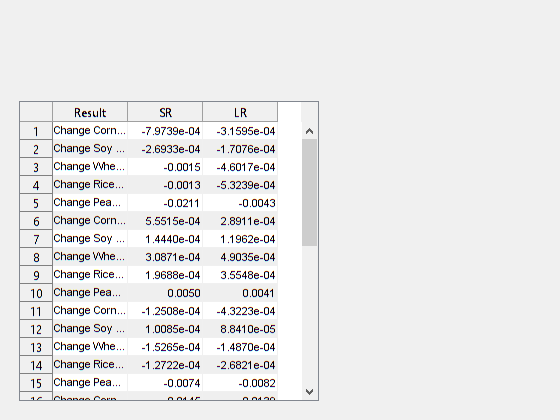

%%

%%

save('Results.({TODAY}).mat', '-struct', 'Results')

%%